# Development and validation of the FAI scale

Measuring the psychological vulerabilities of family caregivers of children with chronic diseases

Author

Corrado Caudek

Published

December 10, 2024

## Background

This study aims to develop a psychological scale to differentiate between family caregivers of children with chronic illnesses based on their coping abilities. This scale will be used to identify caregivers who may benefit from additional support or interventions.

## Constructive Validity

This data analysis può essere considerata come un’analisi di validità costruttiva, che include sia aspetti convergenti che divergenti. L’obiettivo è vedere se le dimensioni del FAI si comportano come previsto in relazione alle dimensioni del COPE e del DASS-21.

## Packages and Options

```r
# Load packages
suppressPackageStartupMessages({
  library(here)
  library(lavaan)
})

# Disable significance stars globally
options(show.signif.stars = FALSE)
```

## Import the Data

```r
# Import RedCap data for the second administration of FAI -----------------

setwd("~/_repositories/meyer_fai/scripts/redcap")

# This will load the necessary libreries
source(here::here("scripts", "redcap", "_targets.R"))

# Read cleaned RedCap data
temp <- tar_read(fai_clean_complete)
# Some cases are empty and will be ignored: 12 18 76 81 152 182 193 202
temp1 <- temp[-c(12, 18, 76, 81, 152, 182, 193, 202), ]
# Remove outlier found with the performance package
fai_clean_complete <- temp1[-92, ]
rm(temp, temp1)

fai <- fai_clean_complete |>
  dplyr::select(
    fai_child_charact, fai_caregiving, fai_cure, fai_intrapsych,
    fai_support, fai_hyper,
    cope_sc1, cope_sc2, cope_sc3, cope_sc4, cope_sc5,
    dass_de_sc, dass_ax_sc, dass_str_sc
  ) |>
  dplyr::rename(
    fai_child_char = fai_child_charact,
    fai_caregiving = fai_caregiving,
    fai_percz_cure = fai_cure,
    fai_intra_psyc = fai_intrapsych,
    fai_soc_fam_sp = fai_support,
    fai_hyper_prot = fai_hyper,
    cope_soc_supp = cope_sc1,
    cope_evit_str = cope_sc2,
    cope_posi_att = cope_sc3,
    cope_prob_ori = cope_sc4,
    cope_tran_ori = cope_sc5,
    dass_de = dass_de_sc,
    dass_ax = dass_ax_sc,
    dass_st = dass_str_sc
  )
```

Descriptive statistics:

```r
psych::describe(fai)
```

```
               vars   n  mean   sd median trimmed  mad min max range  skew
fai_child_char    1 204  1.97 3.14   0.00    1.25 0.00   0  16    16  2.00
fai_caregiving    2 204  2.70 3.55   2.00    1.94 2.97   0  16    16  1.93
fai_percz_cure    3 204 19.88 6.61  21.00   20.56 6.12   0  28    28 -0.76
fai_intra_psyc    4 204 14.92 3.28  15.00   14.97 2.97   7  20    13  0.00
fai_soc_fam_sp    5 204 11.94 2.98  12.00   12.10 2.97   2  16    14 -0.34
fai_hyper_prot    6 204  8.12 3.99   8.00    8.10 4.45   0  16    16  0.04
cope_soc_supp     7 204 27.35 7.64  27.00   27.21 7.41  12  48    36  0.21
cope_evit_str     8 204 20.18 3.55  20.00   19.88 2.97  11  33    22  0.78
cope_posi_att     9 204 29.08 6.83  29.00   29.21 5.93  10  47    37 -0.18
cope_prob_ori    10 204 28.94 6.64  29.17   29.07 5.93  12  45    33 -0.23
cope_tran_ori    11 204 21.62 5.15  20.00   21.56 4.20   4  32    28 -0.23
dass_de          12 204  4.04 3.98   3.00    3.43 4.45   0  19    19  1.38
dass_ax          13 204  4.17 3.99   3.00    3.58 3.41   0  21    21  1.45
dass_st          14 204  6.62 4.49   6.00    6.34 4.45   0  20    20  0.54
               kurtosis   se
fai_child_char     3.82 0.22
fai_caregiving     3.51 0.25
fai_percz_cure     0.24 0.46
fai_intra_psyc    -0.75 0.23
fai_soc_fam_sp    -0.49 0.21
fai_hyper_prot    -0.80 0.28
cope_soc_supp     -0.19 0.53
cope_evit_str      1.18 0.25
cope_posi_att      0.33 0.48
cope_prob_ori      0.22 0.46
cope_tran_ori      1.27 0.36
dass_de            2.06 0.28
dass_ax            2.75 0.28
dass_st           -0.09 0.31
```

Correlazions:

```r
cor(fai) |> round(2)
```

```
               fai_child_char fai_caregiving fai_percz_cure fai_intra_psyc
fai_child_char           1.00           0.58           0.02          -0.11
fai_caregiving           0.58           1.00           0.05          -0.11
fai_percz_cure           0.02           0.05           1.00           0.30
fai_intra_psyc          -0.11          -0.11           0.30           1.00
fai_soc_fam_sp          -0.16          -0.12           0.31           0.49
fai_hyper_prot           0.10           0.18           0.24           0.17
cope_soc_supp            0.10           0.10           0.11          -0.07
cope_evit_str            0.04           0.17           0.04          -0.16
cope_posi_att            0.17           0.18           0.34           0.14
cope_prob_ori            0.05           0.12           0.26           0.12
cope_tran_ori            0.07           0.14           0.17           0.00
dass_de                  0.09           0.13          -0.03          -0.29
dass_ax                  0.06           0.03          -0.06          -0.19
dass_st                  0.09           0.13          -0.04          -0.32
               fai_soc_fam_sp fai_hyper_prot cope_soc_supp cope_evit_str
fai_child_char          -0.16           0.10          0.10          0.04
fai_caregiving          -0.12           0.18          0.10          0.17
fai_percz_cure           0.31           0.24          0.11          0.04
fai_intra_psyc           0.49           0.17         -0.07         -0.16
fai_soc_fam_sp           1.00          -0.02          0.00         -0.17
fai_hyper_prot          -0.02           1.00          0.08          0.30
cope_soc_supp            0.00           0.08          1.00          0.33
cope_evit_str           -0.17           0.30          0.33          1.00
cope_posi_att            0.15           0.16          0.45          0.16
cope_prob_ori            0.05           0.23          0.56          0.28
cope_tran_ori           -0.02           0.03          0.23          0.19
dass_de                 -0.33           0.11          0.32          0.38
dass_ax                 -0.23           0.08          0.37          0.31
dass_st                 -0.33           0.09          0.43          0.32
               cope_posi_att cope_prob_ori cope_tran_ori dass_de dass_ax
fai_child_char          0.17          0.05          0.07    0.09    0.06
fai_caregiving          0.18          0.12          0.14    0.13    0.03
fai_percz_cure          0.34          0.26          0.17   -0.03   -0.06
fai_intra_psyc          0.14          0.12          0.00   -0.29   -0.19
fai_soc_fam_sp          0.15          0.05         -0.02   -0.33   -0.23
fai_hyper_prot          0.16          0.23          0.03    0.11    0.08
cope_soc_supp           0.45          0.56          0.23    0.32    0.37
cope_evit_str           0.16          0.28          0.19    0.38    0.31
cope_posi_att           1.00          0.67          0.17   -0.02   -0.01
cope_prob_ori           0.67          1.00          0.17    0.13    0.17
cope_tran_ori           0.17          0.17          1.00    0.15    0.16
dass_de                -0.02          0.13          0.15    1.00    0.79
dass_ax                -0.01          0.17          0.16    0.79    1.00
dass_st                 0.08          0.24          0.13    0.82    0.78
               dass_st
fai_child_char    0.09
fai_caregiving    0.13
fai_percz_cure   -0.04
fai_intra_psyc   -0.32
fai_soc_fam_sp   -0.33
fai_hyper_prot    0.09
cope_soc_supp     0.43
cope_evit_str     0.32
cope_posi_att     0.08
cope_prob_ori     0.24
cope_tran_ori     0.13
dass_de           0.82
dass_ax           0.78
dass_st           1.00
```

## Principal Component Analysis (PCA)

### COPE

```r
e_fai <- eigen(cov(
  cbind(
    fai$cope_soc_supp, fai$cope_evit_str, fai$cope_posi_att,
    fai$cope_prob_ori, fai$cope_tran_ori
    )
  )
)
e_fai$values / sum(e_fai$values)
```

```
[1] 0.57282479 0.16542178 0.12936662 0.07778636 0.05460045
```

```r
cope_data <- fai[, c(
  "cope_soc_supp", "cope_evit_str", "cope_posi_att","cope_prob_ori",
  "cope_tran_ori")]
pca_cope <- prcomp(cope_data, scale. = TRUE)
pca_cope
```

```
Standard deviations (1, .., p=5):
[1] 1.5394205 0.9903946 0.9054336 0.7213615 0.5559950

Rotation (n x k) = (5 x 5):
                    PC1          PC2          PC3         PC4         PC5
cope_soc_supp 0.5126689 -0.008089375 -0.100656905 -0.82578331  0.21226229
cope_evit_str 0.3268759  0.537117727 -0.709502276  0.30631655  0.08621709
cope_posi_att 0.5064122 -0.382217009  0.208853723  0.44584515  0.59586833
cope_prob_ori 0.5533473 -0.286768511  0.008403472  0.14794397 -0.76786230
cope_tran_ori 0.2601465  0.695063370  0.665420327  0.05988972 -0.05328921
```

Estrarre i punteggi delle prime 2 componenti principali:

```r
fai$COPE_PC1 <- pca_cope$x[, 1]
fai$COPE_PC2 <- pca_cope$x[, 2]
```

### DASS-21

```r
e_dass <- eigen(cov(cbind(fai$dass_de, fai$dass_ax, fai$dass_st)))
e_dass$values / sum(e_dass$values)
```

```
[1] 0.86687628 0.07397738 0.05914634
```

PCA

```r
dass_data <- fai[, c("dass_de", "dass_ax", "dass_st"), ]
pca_dass <- prcomp(dass_data, scale. = TRUE)
pca_dass
```

```
Standard deviations (1, .., p=3):
[1] 1.6114837 0.4710503 0.4257135

Rotation (n x k) = (3 x 3):
              PC1        PC2        PC3
dass_de 0.5808870  0.2999018  0.7567227
dass_ax 0.5725955 -0.8112998 -0.1180129
dass_st 0.5785367  0.5018481 -0.6429959
```

Extract scores of PC1:

```r
fai$DASS_PC1 <- pca_dass$x[, 1]
```

#### Results

1. **COPE Dimensions:**
   - **COPE_PC1 (57.3% variance explained):** Represents a general dimension of positive coping, with high loadings on **social support**, **positive attitude**, and **problem orientation**.
   - **COPE_PC2 (16.5% variance explained):** Reflects a mix of avoidant and transcendent coping strategies, with high loadings on **avoidance strategies** and **transcendent orientation**.
2. **DASS Dimensions:**
   - **DASS_PC1 (86.7% variance explained):** Represents overall psychological distress, with balanced contributions from **depression**, **anxiety**, and **stress**.
   - Higher-order components, **DASS_PC2** and **DASS_PC3**, explain minimal variance (7.4% and 5.9%, respectively) and were not considered for the MANOVA due to their limited relevance.

### Multivariate Analysis of Variance

We conducted a MANOVA to investigate the multivariate effects of COPE_PC1 (positive coping), COPE_PC2 (avoidant/transcendent coping), and DASS_PC1 (distress) on six dimensions of the Family Adjustment Inventory (FAI): child characteristics, caregiving demands, perception of formal care, intrapsychic factors, social support/family functioning, and hyper-protectiveness.

```r
manova_fit <- manova(
  cbind(
    fai_child_char, fai_caregiving, fai_percz_cure,
    fai_intra_psyc, fai_soc_fam_sp, fai_hyper_prot
  ) ~ COPE_PC1 + COPE_PC2 + DASS_PC1,
  data = fai
)
```

```r
summary(manova_fit)
```

```
           Df   Pillai approx F num Df den Df    Pr(>F)
COPE_PC1    1 0.134339   5.0436      6    195 7.847e-05
COPE_PC2    1 0.064446   2.2388      6    195 0.0411350
DASS_PC1    1 0.125719   4.6734      6    195 0.0001824
Residuals 200
```

#### Results

The MANOVA revealed the following effects on the combined six dimensions of the FAI:

| Predictor | Pillai’s Trace | F (approx) | df (num) | df (den) | p-value |
| --- | --- | --- | --- | --- | --- |
| **COPE_PC1** | 0.134 | 5.04 | 6 | 195 | < 0.001 |
| **COPE_PC2** | 0.064 | 2.24 | 6 | 195 | 0.041 |
| **DASS_PC1** | 0.126 | 4.67 | 6 | 195 | < 0.001 |

- **COPE_PC1** (positive coping) and **DASS_PC1** (distress) had significant multivariate effects across the FAI dimensions, indicating that these factors strongly influence family adjustment.
- **COPE_PC2** (avoidant/transcendent coping) demonstrated a weaker but significant effect, suggesting that certain avoidant or transcendent strategies might play a role in family dynamics.

#### **Conclusions**

The results emphasize the dual importance of reducing psychological distress (DASS_PC1) and promoting adaptive coping strategies (COPE_PC1) to enhance family adjustment. These findings suggest that clinical interventions should aim to strengthen problem-focused coping while addressing the emotional and psychological burdens of caregivers.

#### **Future Directions**

Post-hoc univariate analyses will be conducted to determine which specific FAI dimensions are most affected by the predictors, providing additional insights into targeted intervention strategies. Interactions between predictors (e.g., COPE_PC1 × DASS_PC1) may also be explored to examine whether positive coping moderates the impact of psychological distress.

## Modeling interactions

Testing whether the effect of COPE_PC1 (positive coping) is moderated by DASS_PC1 (psychological distress). This would test the hypothesis that positive coping attenuates the impact of psychological distress.

```r
manova_fit_inter <- manova(
  cbind(
    fai_child_char, fai_caregiving, fai_percz_cure,
    fai_intra_psyc, fai_soc_fam_sp, fai_hyper_prot
  ) ~
    COPE_PC1 * DASS_PC1 + COPE_PC2,
  data = fai
)
summary(manova_fit_inter)
```

```
                   Df   Pillai approx F num Df den Df    Pr(>F)
COPE_PC1            1 0.134356   5.0184      6    194 8.340e-05
DASS_PC1            1 0.166673   6.4669      6    194 3.111e-06
COPE_PC2            1 0.031824   1.0628      6    194  0.386360
COPE_PC1:DASS_PC1   1 0.096646   3.4592      6    194  0.002862
Residuals         199
```

```r
# Fit a separate linear model for a specific dimension
lm_fai_intra_psyc <- lm(
  fai_intra_psyc ~ COPE_PC1 * DASS_PC1 + COPE_PC2,
  data = fai
)

# Summary to check interaction significance
summary(lm_fai_intra_psyc)
```

```
Call:
lm(formula = fai_intra_psyc ~ COPE_PC1 * DASS_PC1 + COPE_PC2,
    data = fai)

Residuals:
    Min      1Q  Median      3Q     Max
-8.7514 -2.1955 -0.1202  2.4108  6.9690

Coefficients:
                  Estimate Std. Error t value Pr(>|t|)
(Intercept)       14.70137    0.22431  65.541  < 2e-16
COPE_PC1           0.48889    0.16110   3.035  0.00273
DASS_PC1          -0.77788    0.15324  -5.076 8.82e-07
COPE_PC2          -0.32776    0.22365  -1.466  0.14436
COPE_PC1:DASS_PC1  0.28670    0.08793   3.261  0.00131

Residual standard error: 3.05 on 199 degrees of freedom
Multiple R-squared:  0.1541,    Adjusted R-squared:  0.1371
F-statistic: 9.062 on 4 and 199 DF,  p-value: 9.596e-07
```

```r
# Create a grid of values for COPE_PC1 and DASS_PC1
cope_pc1_seq <- seq(min(fai$COPE_PC1), max(fai$COPE_PC1), length.out = 100)
dass_pc1_seq <- seq(min(fai$DASS_PC1), max(fai$DASS_PC1), length.out = 100)

# Create grid
grid <- expand.grid(COPE_PC1 = cope_pc1_seq, DASS_PC1 = dass_pc1_seq)

# Use the mean value of COPE_PC2 for predictions
grid$COPE_PC2 <- mean(fai$COPE_PC2)

# Predict using the fitted model
grid$Predicted <- predict(lm_fai_intra_psyc, newdata = grid)

# Predict using the fitted model
grid$Predicted <- predict(lm_fai_intra_psyc, newdata = grid)
```

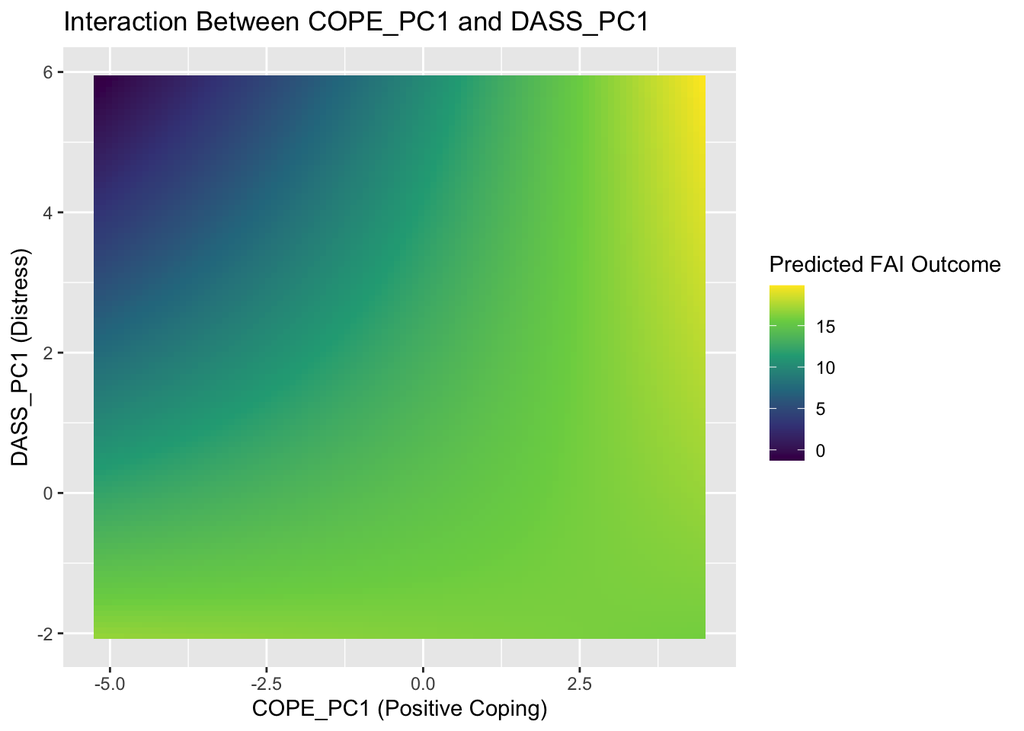

```r
ggplot(grid, aes(x = COPE_PC1, y = DASS_PC1, fill = Predicted)) +
  geom_tile() +
  scale_fill_viridis_c() +
  labs(
    title = "Interaction Between COPE_PC1 and DASS_PC1",
    x = "COPE_PC1 (Positive Coping)",
    y = "DASS_PC1 (Distress)",
    fill = "Predicted FAI Outcome"
  )
```

The interaction between COPE_PC1 and DASS_PC1 highlights the buffering effect of positive coping strategies on family adjustment outcomes. Specifically, families with higher levels of positive coping (COPE_PC1) demonstrated resilience to psychological distress (DASS_PC1), maintaining better adjustment outcomes even under high distress conditions. Conversely, families with low positive coping and high distress exhibited significantly poorer outcomes, suggesting a synergistic impact of low coping resources and high distress on family functioning. Sica et al. (2021)

## Bibliography

Sica, Claudio, Robert D Latzman, Corrado Caudek, Silvia Cerea, Ilaria Colpizzi, Maria Caruso, Paolo Giulini, and Gioia Bottesi. 2021. “Facing Distress in Coronavirus Era: The Role of Maladaptive Personality Traits and Coping Strategies.” *Personality and Individual Differences* 177: 110833.